# Day 1, Lab 1

In this notebook, we will be exploring some of the concepts on population projection and stable population theory.

## Lab I: Introduction to the data and measures of reproduction

The aim of the first section of this lab is to introduce you to the dataset that we’ll be using, and to warm-up using R a little bit.

The dataset has values for $_nL_x$ (person-years lived between ages $x$ and $x+n$), $_nF_x$ (age-specific fertility) and $_nK_x$ (population between ages $x$ and $x+n$) for six countries, which have different types of mortality, fertility and age structures:

- Australia
- Kenya
- Singapore
- Niger
- Russia
- Senegal

Data are for females in 2015 and were obtained from the [World Health Organisation](http://apps.who.int/gho/data/node.main.687?lang=en) ($_nL_x$) and [United Nations Population Division](https://esa.un.org/unpd/wpp/) ($_nF_x$ and $_nK_x$).

```r
d <- read_csv("../bfdw_projection_data.csv")
```

Throughout this lab, we’ll be making use of the `%>%` operator. This is like a ‘pipe’, which takes whatever is on the left hand side and feeds it forward into a function. For example, below we are taking our data `d`, filtering it to only include Australia, and then printing the head (the first six rows).

```r
d %>%
  filter(country=="Australia") %>%
  head
```

| age | country | nLx | nKx | nFx |
| --- | --- | --- | --- | --- |
| 0 | Australia | 498495.3 | 751.868 | 0.000 |
| 5 | Australia | 498195.5 | 740.330 | 0.000 |
| 10 | Australia | 497994.4 | 688.526 | 0.000 |
| 15 | Australia | 497637.1 | 717.395 | 15.527 |
| 20 | Australia | 497040.3 | 812.546 | 52.881 |
| 25 | Australia | 496408.8 | 884.737 | 102.093 |

Notice that:

- The magnitude of $_nL_x$ values suggests a radix of 100,000
- $_nF_x$ is the age-specific birth rate per 1,000 women
- $_nK_x$ is age-specific population in 000s

To save trouble later, let’s change $_nL_x$ to have a radix of 1, and $_nF_x$ to have units births per woman.

```r
d <- d %>%
  mutate(nLx = nLx/10^5,
         nFx = nFx/1000)
```

### Person-years lived: $_nL_x$

Let’s investigate the values of $_nL_x$ by country. First, let’s calculate the life expectancy at birth, $e_0$, for all countries. Remember that
$$e_0 =
\frac{\sum {_nL_x}}{l_0}$$

To calculate in R we can use `group_by` to do the calculation separately for each country.

```r
# calculate life expectancy at birth
# we know radix is 1
radix <- 1

d %>%
  group_by(country) %>%
  summarise(e0 = sum(nLx)/radix) %>%
  arrange(e0) # arrange by increasing life expectancy
```

| country | e0 |
| --- | --- |
| Niger | 62.81483 |
| Kenya | 65.76719 |
| Senegal | 68.64102 |
| Russia | 76.28231 |
| Australia | 84.77169 |
| Singapore | 86.12643 |

There is more than 23 years difference in the life expectancy at birth for females in Niger compared to Singapore.

### Fertility rates: $_nF_x$

Here, we will quickly review a few basic measures of fertility and reproduction.

Remember that the Total Fertility Rate, TFR, is

$$TFR = \sum {_nF_x} \cdot
n.$$

The Gross Reproduction Ratio, GRR, is

$$GRR = TFR \cdot f_{fab}.$$
The Net Reproduction Ratio, NRR, is

$$NRR = \frac{\sum {_nF_x}\cdot {_nL_x}
\cdot f_{fab}}{l_0}.$$

Finally, the mean age at childbearing is

$$\mu = \frac{\sum (x+2.5)\cdot {_nF_x}\cdot {_nL_x}}{\sum \cdot
{_nF_x}\cdot {_nL_x}}.$$

```r
# calculate TFR, GRR and NRR by country
# set fraction female at birth to be 0.4886
ffab <- 0.4486

d_reproduction <- d %>%
  filter(age>=15, age < 50) %>% # restrict our dataset to be fertility rates for women aged 15-49
  group_by(country) %>%
  summarise(tfr = sum(nFx*5),
            grr = tfr*ffab,
            nrr = sum(nFx*nLx*ffab/radix),
            mu = sum((age+2.5)*nFx*nLx)/sum(nFx*nLx)) %>%
  arrange(tfr)

d_reproduction
```

| country | tfr | grr | nrr | mu |
| --- | --- | --- | --- | --- |
| Singapore | 1.2330 | 0.5531238 | 0.5488301 | 31.20340 |
| Russia | 1.6618 | 0.7454835 | 0.7298747 | 27.71176 |
| Australia | 1.9174 | 0.8601456 | 0.8528190 | 30.52732 |
| Kenya | 4.4371 | 1.9904831 | 1.7813249 | 28.61942 |
| Senegal | 5.1815 | 2.3244209 | 2.1388976 | 29.79319 |
| Niger | 7.6335 | 3.4243881 | 2.9402759 | 28.85743 |

We can plot the age-specific fertility rates for each country.

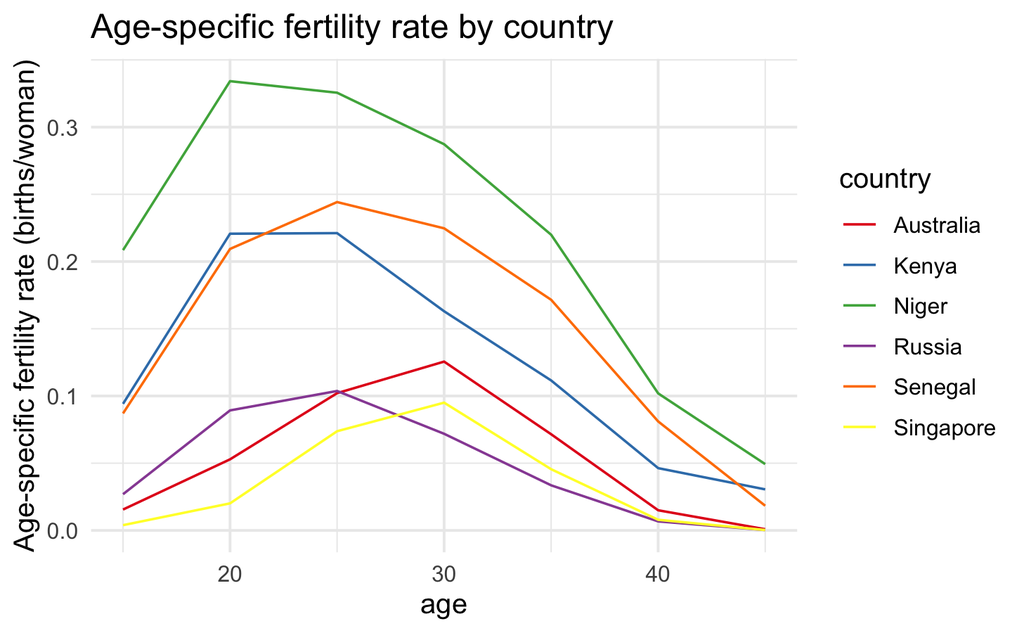

```r
# create a dataset which only has reproductive ages (15-49)
d_rpa <- d %>% filter(age >= 15, age < 50)

# plot age-specific fertility rates
ggplot(data = d_rpa, aes(x = age, y = nFx, color = country)) +
  geom_line()+
  ylab("Age-specific fertility rate (births/woman)")+
  ggtitle("Age-specific fertility rate by country")+
  scale_color_brewer(palette="Set1") +
  theme_minimal(base_size = 12) ## change ggplot default theme
```

We can also plot the proportion of the population in each age group. This is like half of a population pyramid (the female half). First we need to calculate the proportion in each age group from the raw numbers.

```r
# let's calculate the proportion in each age group so we can compare across countries
d <- d %>%
  group_by(country) %>%
  mutate(nCx = nKx/sum(nKx))
```

Now we can plot the female half of the population pyramid for each country

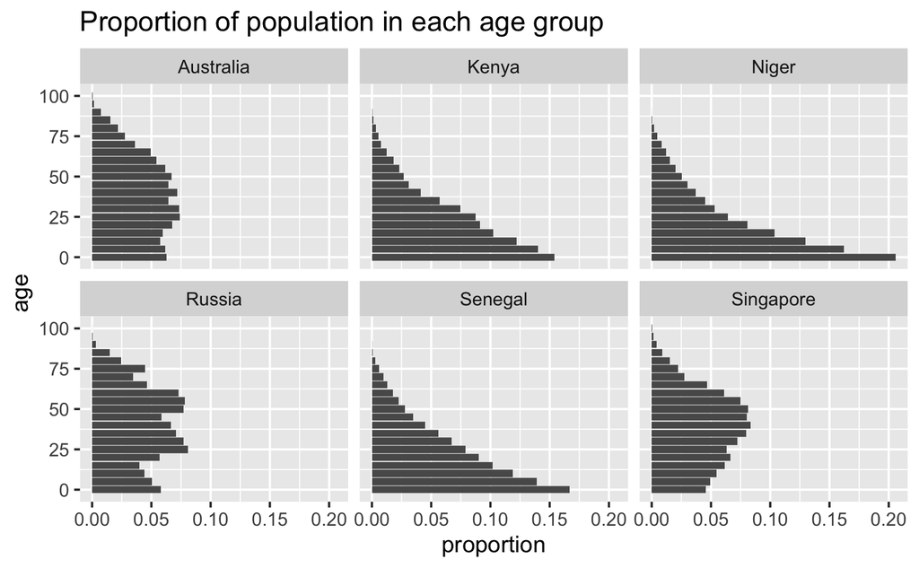

```r
ggplot(d, aes(x = age, y = nCx)) +
  facet_wrap(~country, ncol=3)+
  geom_bar(stat="identity", position = "dodge")+
  ggtitle("Proportion of population in each age group")+
  ylab("proportion")+
  coord_flip()
```

## Exercises

> **Q1**. Suppose that a population has K(2010) = 7,886,000 people in 2010 and then K(2015) = 7,879,000 five years later. Use R to calculate the growth rate $R$ of the population over this interval.

BEGIN SOLUTION:

We can calculate the growth rate from $K(2015) = \exp(R5)K(2010)$. Rearranging, we see that $\frac{K(2015)}{K(2010)} = \exp(R5)$, or $(1/5) [\log(K(2015)) - \log(K(2010))] = R$.

```r
K2010 <- 7886000
K2015 <- 7879000

growth_rate_R <- (log(K2015) - log(K2010))/5
growth_rate_R
```

```
[1] -0.0001776086
```

END SOLUTION

> **Q2.** Given your answer to question (1), in what year would you expect the population to fall below 7 million?

BEGIN SOLUTION

We want to find $t$ satisfying $7 \times 10^{6} = K(2010) \exp(Rt)$. Rearranging and solving for $t$, we have $(1/R)[ \log(7 \times 10^6) - \log(K(2010))] = t$.

```r
target_time_span <- (1/growth_rate_R) * ( log(7e6) - log(K2010))
target_time_span
```

```
[1] 671.0197
```

The actual year is given by this target_time_span plus the starting year, 2010

```r
target_time_span + 2010
```

```
[1] 2681.02
```

This is very far away! This reflects the fact that the growth rate is negative, but very small. So it takes a long time for the population to shrink

END SOLUTION